# Using R Markdown with RStudio

## Markdown Basics

Use an asterisk mark to provide emphasis such as *italics* and **bold**.

Create lists with a dash: - Item 1 - Item 2 - Item 3

You can write `in-line` code with a back-tick.

```
Code blocks display
with fixed-width font
```

> Blockquotes are offset

Note that the toolbar provides some usefile tools for working with R Markdown:

- **Quick Reference** - Click the **MD** toolbar button to open a quick reference quide for Markdown.
- **Knit HTML** - Click to knit the current document to HTML, see the **Knitting to HTML** section below for more details.
- **Run** - Run the current line or selection of lines in the console. This allows running R code inside a code chunk similar to a normal R sourch file.
- **Chunks** - The chunks menu provides assistance with inserting, running, and chunk navigation.

## Embedding R Code Chunks

Within an R Markdown file, R code chunks can be embedded using the native Markdown syntax for code regions

```r
# R code goes here
```

For example, the following code chunk filters data and renders a plot as a PNG image. It then embeds the results within a standalone HTML file:

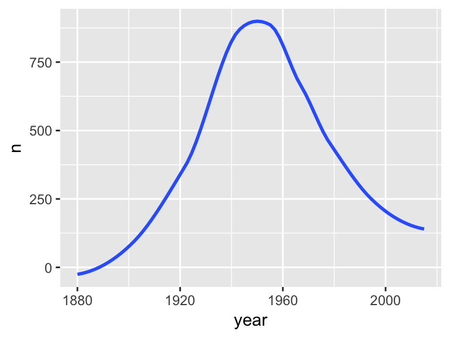

```r
# quick summary and plot (use install.packages() if you haven't installed them yet)

library(dplyr)
library(ggplot2)
library(babynames)

dwight_data <- babynames %>%
  filter(name == "Dwight")

ggplot(aes(x = year, y = n), data = dwight_data) +
  geom_smooth(method = "loess", se = FALSE)
```

## Embedding Inline R Code

You can also evaluate R expressions inline by enclosing the expression within a single back-tick qualified with ‘r’. For example, the following code:

```r
# I counted `r 1 + 1` red trucks on the highway.
```

Results in this output: I counted 2 red trucks on the highway.

## Navigating Between Chunks

A popup navigation menu is located at the bottom of the editor based on the chunk labels (optional) in your Rmd file. This makes editing and navigating between chunks easy.

## Using the Chunk Menu

The Chunk Menu makes it easy to insert new chunks and execute R code from within an R Markdown document.

- **Insert Chunk** - Inserts the basic syntax for an embedded R code chunk
- **Up/down arrow** - Jumps to the previous or next code chunk
- **Run Current/Next Chunk** - Runs the current (or next) code chunk based on the cursor position. You can use this to iteratively step through code chunks one-by-one to test your R code. This interacts with the console and acts upon the current global environment.
- **Run All** - Run all R code chunks in the current document.